# 苏宁小店用户价值类别判定

### 用户特征值主要分布区间概览

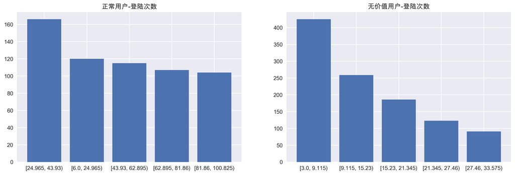

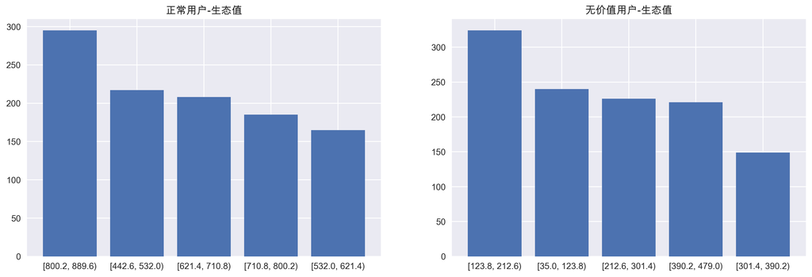

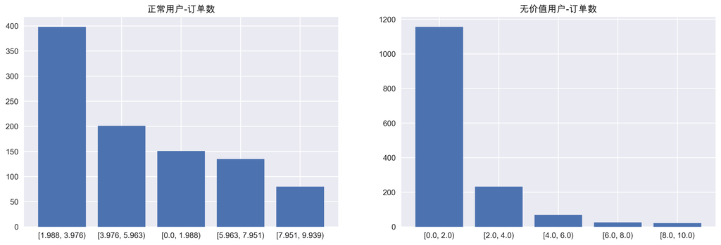

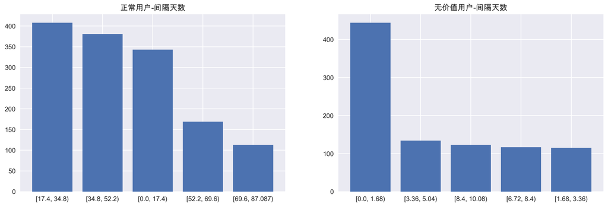

```python
val=users[users['用户类别']==1]
unval=users[users['用户类别']==0]

result=pd.cut(val['登陆次数'].to_numpy(),800,False)
loga=pd.value_counts(result)
loga_idx=loga.index.values.tolist()
loga_idx=list(map(lambda x:str(x),loga_idx))

result=pd.cut(unval['登陆次数'].to_numpy(),800,False)
logb=pd.value_counts(result)
logb_idx=logb.index.values.tolist()
logb_idx=list(map(lambda x:str(x),logb_idx))

result=pd.cut(val['生态值'].to_numpy(),10,False)
soca=pd.value_counts(result)
soca_idx=soca.index.values.tolist()
soca_idx=list(map(lambda x:str(x),soca_idx))

result=pd.cut(unval['生态值'].to_numpy(),10,False)
socb=pd.value_counts(result)
socb_idx=socb.index.values.tolist()
socb_idx=list(map(lambda x:str(x),socb_idx))

result=pd.cut(val['订单数'].to_numpy(),245,False)
orda=pd.value_counts(result)
orda_idx=orda.index.values.tolist()
orda_idx=list(map(lambda x:str(x),orda_idx))

result=pd.cut(unval['订单数'].to_numpy(),90,False)
ordb=pd.value_counts(result)
ordb_idx=ordb.index.values.tolist()
ordb_idx=list(map(lambda x:str(x),ordb_idx))

result=pd.cut(val['间隔天数'].to_numpy(),5,False)
itva=pd.value_counts(result)
itva_idx=itva.index.values.tolist()
itva_idx=list(map(lambda x:str(x),itva_idx))

result=pd.cut(unval['间隔天数'].to_numpy(),50,False)
itvb=pd.value_counts(result)
itvb_idx=itvb.index.values.tolist()
itvb_idx=list(map(lambda x:str(x),itvb_idx))

fig1=plt.figure(1,figsize=(16,5),dpi=300)
ax1 = fig1.add_subplot(1,2,1,title='正常用户-登陆次数')
_=ax1.bar(loga_idx[:5],loga[:5])
ax2 = fig1.add_subplot(1,2,2,title='无价值用户-登陆次数')
_=ax2.bar(logb_idx[:5],logb[:5])

fig2=plt.figure(2,figsize=(16,5),dpi=300)
ax3 = fig2.add_subplot(1,2,1,title='正常用户-生态值')
_=ax3.bar(soca_idx[:5],soca[:5])
ax4 = fig2.add_subplot(1,2,2,title='无价值用户-生态值')
_=ax4.bar(socb_idx[:5],socb[:5])

fig3=plt.figure(3,figsize=(16,5),dpi=300)
ax5 = fig3.add_subplot(1,2,1,title='正常用户-订单数')
_=ax5.bar(orda_idx[:5],orda[:5])
ax6 = fig3.add_subplot(1,2,2,title='无价值用户-订单数')
_=ax6.bar(ordb_idx[:5],ordb[:5])

fig4=plt.figure(4,figsize=(16,5),dpi=300)
ax7 = fig4.add_subplot(1,2,1,title='正常用户-间隔天数')
_=ax7.bar(itva_idx[:5],itva[:5])
ax8 = fig4.add_subplot(1,2,2,title='无价值用户-间隔天数')
_=ax8.bar(itvb_idx[:5],itvb[:5])
```

### 交叉对比不同类别用户间的特征行为

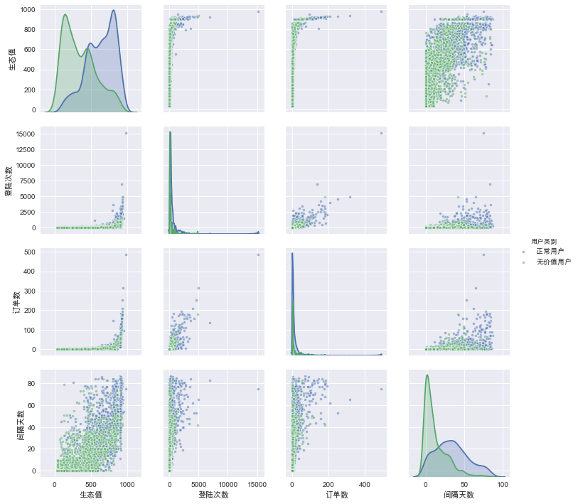

```python
u=users.drop(['用户编号','注册时间','首次购买时间','当天购买'],axis=1)
def fn(x):
    if x['用户类别']==1:
        x['用户类别']='正常用户'
    if x['用户类别']==0:
        x['用户类别']='无价值用户'
    return x
u=u.apply(fn,axis=1)
_=sns.pairplot(u,hue='用户类别',diag_kind='kde',plot_kws={"alpha":0.5,'s':16})
```

## 建模预测各指标对于判定用户价值类别的影响

### 综合对比两种价值类别用户指标

```python
users_mean = users.groupby('用户类别').mean().rename(index={0: '无价值用户', 1: '正常用户'})
users_mean.drop(['用户编号','注册时间','首次购买时间'],axis=1,inplace=True)
users_mean.index.name=''
users_mean.index=['无价值用户','正常用户']
users_mean
```

|  | 生态值 | 登陆次数 | 订单数 | 间隔天数 | 当天购买 |
| --- | --- | --- | --- | --- | --- |
| 无价值用户 | 351.940731 | 58.665826 | 2.892812 | 12.550441 | 0.279950 |
| 正常用户 | 631.681754 | 321.057992 | 14.777935 | 34.040311 | 0.053041 |

[figure not shown]

```python
um=users_mean.copy()
def scale(x):
    s=x.sum()
    x[0]=x[0]/s
    x[1]=x[1]/s
    return x
um_scale=um.apply(scale)
x1,x2,unvalued,valued=[1,2,3,4,5],[1.3, 2.3, 3.3, 4.3, 5.3],um_scale.iloc[0],um_scale.iloc[1]
# plt.figure(figsize=(16,8)) #调整画布大小
plt.grid(linewidth=0) #网格
plt.bar(x1,unvalued,width=0.3) #无价值用户
plt.bar(x2,valued,width=0.3,) #有价值用户
plt.legend(['无价值用户','正常用户'],fontsize=15) #说明
plt.xticks([1.15, 2.15, 3.15, 4.15, 5.15], ['登陆次数比','生态值比','订单数比','间隔天数比','当天购买比'],fontsize=13)
plt.yticks([0,1.1],[])

for i,j in zip(x1,unvalued):
    plt.text(i,j,'%.2f' % j,ha='center',va='bottom',fontsize=15)

for i,j in zip(x2, valued):
    plt.text(i,j,'%.2f' % j,ha='center',va='bottom',fontsize=15)
```

### 使用逻辑回归建模分析

```python
features=users.drop(['用户编号','注册时间','首次购买时间','用户类别'],axis=1) # 特征值

targets=users['用户类别'] # 目标值

# 对特征值进行标准化预处理
from sklearn.preprocessing import StandardScaler
ss=StandardScaler()
features=ss.fit_transform(features)

# 使用逻辑回归建模
from sklearn.linear_model import LogisticRegression
lgr=LogisticRegression()
_=lgr.fit(features,targets)
```

### 模型拟合程度和模型误差

```python
print('模型拟合程度:',lgr.score(features,targets))
print('模型误差:',lgr.intercept_[0])
```

```
模型拟合程度: 0.7556666666666667
模型误差: -0.1128904032358629
```

### 各特征相对标签影响大小

[figure not shown]

```python
impact = pd.Series(lgr.coef_[0], index=['登陆次数', '生态值', '订单数', '间隔天数', '是否当天购买']) # 将特征名称和特征系数组合为Series数据
rank=impact.sort_values(ascending=False)
plt.figure(figsize=(12,8))
plt.xticks(fontsize=15)
plt.yticks(fontsize=15)
plt.bar(rank.index.values,rank)
for i,j in zip(rank.index.values, rank):
    plt.text(i,j,'%.5f' % j,ha='center',va='bottom',alpha = 0.8,fontsize=15)
```

# 研究结论

## 基础数据对比

#### 平均登陆次数

- 正常用户：321.06次
- 无价值用户：58.67次

#### 平均生态值

- 正常用户：631.68
- 无价值用户：351.94

#### 平均订单数

- 正常用户：14.78单
- 无价值用户：2.89单

#### 平均首次购买时间间隔

- 正常用户：34.04天
- 无价值用户：12.55天

#### 注册当天购买比例

- 正常用户：5.3%
- 无价值用户：27.99%

### 整体差异

与正常用户相比,无价值用户

- 登陆次数**更少**
- 生态值**更少**
- 购买量**更少**
- 注册后的首次购买间隔**更短**

整体来看,商品的优惠区间主要集中在**10元内** 最受欢迎的商品主要是**水果类和速食类**，折后最受欢迎的商品多为**果蔬类**

## 用户画像

典型的正常用户:

- 注册后一般不会当天购买,约50%的可能会在注册一个月内随机时间段完成首单购买,约30%可能会在注册后第一到第二个月间完成首单购买
- 苏宁生态值大多在500以上
- 会经常打开APP查看,活跃度较高,极有可能同时使用其他苏宁产品
- 在完成新用户优惠订单后仍能保持购买力

典型的无价值用户:

- 注册后约30%的可能在48小时内完成首单购买,约70%可能会在10天内完成首单购买
- 苏宁生态值大多在500以下
- 很少打开APP查看,最终登陆次数约70%可能在30次以内
- 80%的可能只会购买一次到两次,之后极小可能再使用APP下单购买商品

## 意见与建议

- 推广
  - 整体来看最受欢迎的商品多为果蔬类商品和速食类商品，可以适当增加铺货和推广。
  - 可在苏宁系产品内增加适当推广量，吸引活跃用户注册后的价值用户转化率相对从外部引流较高。
  - 向正常用户推广优质商品，向无价值用户推广高性价比商品。
- 用户关系维系
  - 对于SUPER VIP会员进行周期返优惠券或提供部分热门商品的特有额度以维持用户购买力。
  - 对SUPER VIP会员开放等级机制，通过消费水平、活跃度等判定等级，等级越高享有更多专享折扣与更高质量服务，增加用户的转移成本。
  - 除每日签到外还可以增加小游戏任务，提高用户登陆次数，在相关页面内增加商品推送并阶段性提供奖励,以维系用户活跃度。
- 价值用户转化
  - 针对用户注册后使用完新用户优惠后就极少或不再使用的问题，可将新用户发放的优惠券分拆为多张小额度无门槛券，吸引用户多次购买，并在此过程中增加喜欢购买商品类型的精准推送。
  - 向新注册用户提供试用会员服务，享有部分或全部会员折扣，以刺激用户购买和转化。
  - 将优惠商品与正价商品打包组合销售。
- 其他建议
  - 可在APP内增加易购、乐拼购或其他苏宁系产品的推广或购买方式，增加用户购买选择多样性，同时可将外部引流的用户再向其他苏宁系产品新用户转化。